# Assignment 6: Kernels

This material, no matter whether in printed or electronic form, may be used for personal and non-commercial educational use only. Any reproduction of this material, no matter whether as a whole or in parts, no matter whether in printed or in electronic form, requires explicit prior acceptance of the authors.

## Task 1: RBF kernel is indeed a kernel

The aim of this task is to give you some familiarity with kernels. We will walk you through the procedure of showing that certain functions can be used as kernels, thus defining inner products in higher dimensional spaces. Specifically, we want to do this for the most frequently used one, namely the RBF (radial basis function) kernel. This requires several preparation steps. Let us start by recalling the notion of a kernel: A map $k: X \times X \to \mathbf{R}$ is called a kernel, if it is positive semi-definite (1) and symmetric (2), i.e.

\begin{align*} \sum_{i,j} c_i k(\mathbf{x}^i,\mathbf{x}^j) c_j \geq 0 \quad &(1) \\ k(\mathbf{x}^i,\mathbf{x}^j)=k(\mathbf{x}^j,\mathbf{x}^i) \quad &(2) \end{align*}

for $i=1,...,l$, $c_i \in \mathbb{R}$, $\mathbf{x}^i \in X$. An important observation is that (1) and (2) are equivalent to the statement that the gram matrix $\mathbf{K}=(k_{ij})_{i=1,\dots,l}^{j=1\dots,l}=(k(\mathbf{x}^i,\mathbf{x}^j))_{i=1,\dots,l}^{j=1\dots,l}$ is positive semi-definite and symmetric.

Moreover, kernels have the important property that their existence is equivalent to the existence of a Hilbert space $\mathcal{H}$ and a feature mapping $\Phi: X\rightarrow\mathcal{H}$ such that $k(\mathbf{x},\mathbf{y})=\Phi(\mathbf{x})\cdot\Phi(\mathbf{y})$, where $\cdot$ denotes the inner product in $\mathcal{H}$. The important point here is that you don't have to know $\Phi$ and the feature space $\mathcal{H}$ explicitely: the most important characteristic of the Hilbert space, namely the inner product, can be specified by $k$ only. So the crucial point in order to get a suitable feature representation will be the choice of $k$.

### Task:

From here on out let's assume $X=\mathbb{R}^n$. The easiest kernel that all of you know for sure, is just given by the usual inner product in $\mathbf{R}^n$, i.e. $k(\mathbf{x},\mathbf{y})=\mathbf{x}^T \mathbf{y}$ for $\mathbf{x},\mathbf{y} \in X$. In the first task ensure that this is indeed a kernel by verifying (1) and (2).

### Calculation (10 Points):

Prrof: The kerenl is semi definite as \begin{align*} \sum_{i,j}c_{i}k(\mathbf{x}^{i},\mathbf{x}^{j})c_{j}=\sum_{i,j}c_{i}(\mathbf{x}^{i})^{T}\mathbf{x}^{j}c_{j}=\sum_{i}c_{i}(\mathbf{x}^{i})^{T}\sum_{j}\mathbf{x}^{j}c_{j}=\left\Vert \sum_{i}\mathbf{x}^{i}c_{i}\right\Vert ^{2}\geq0 \end{align*}

and is symmetric as \begin{align*} k(\mathbf{x}^{i},\mathbf{x}^{j})=(\mathbf{x}^{i})^{T}\mathbf{x}^{j}=\sum_{l=1}^{n}\mathbf{x}_{l}^{i}\mathbf{x}_{l}^{j}=\sum_{l=1}^{n}\mathbf{x}_{l}^{j}\mathbf{x}_{l}^{i}=(\mathbf{x}^{j})^{T}\mathbf{x}^{i}=k(\mathbf{x}^{j},\mathbf{x}^{i}) \end{align*}

In applications, however, the most frequently used kernel is the Gaussian kernel, or RBF-kernel: for $\mathbf{x},\mathbf{y} \in X$, and some $\sigma \in \mathbb{R}$, $k(\mathbf{x},\mathbf{y})=\exp\!\big(\!-\!\frac{1}{2\sigma^2}\|\mathbf{x}-\mathbf{y}\|^2\big)$. Since the value of the RBF kernel decreases with distance and ranges between $0$ (in the limit) and $1$ (if $\mathbf{x}=\mathbf{y}$), it has a useful interpretation as a similarity measure. Symmetry of this kernel is clear immediately (make sure that you understand why!). Showing that this is also positive semidefinite is not as easy any more and will be, as already mentioned, the main task of this assignment. Instead of directly looking at (1), we will go a different way by ensuring the kernel property using several small steps. This procedure has the advantage that we will also prove several important general properties of kernels along the way, which turn out to be very useful in constructing new ones from already known ones.

Let us start by showing that for $\alpha \geq 0$ and a given kernel $k$, also $\alpha k$ is a kernel. We will here provide two possible proofs of this fact, so that it is hopefully easier for you to also master the remaining tasks by recognizig the available tools.

- If $\mathbf{K}$ is the Gram matrix associated to $k$, then clearly $\alpha \mathbf{K}$ is the Gram matrix associated to $\alpha k$. But then for any $\mathbf{c} \in \mathbb{R}^l$: $\mathbf{c}^T \alpha \mathbf{K} \mathbf{c}= \alpha \mathbf{c}^T \mathbf{K} \mathbf{c} \geq 0$, since $\mathbf{K}$ is positive semidefinite and $\alpha \geq 0$. Therefore $\alpha \mathbf{K}$ is again positive semidefinite, and therefore $\alpha k$ is a kernel.
- Let $\Phi$ be the feature map associated to $k$. We will show that $\sqrt{\alpha}\,\Phi$ is the feature map associated to $\alpha k$. We calculate $\sqrt{\alpha}\,\Phi(\mathbf{x})\cdot \sqrt{\alpha}\,\Phi(\mathbf{y})=\alpha k(\mathbf{x},\mathbf{y})$ for any $\mathbf{x},\mathbf{y} \in X$

Both of these provided approaches might turn out to be useful, and it is, first of all, a good idea to make sure that you understand their meaning. With these preparation steps, you should now be able to proceed with the following task:

### Task:

Show that for two kernels $k$ and $k'$, $k+k'$ is again a kernel.

### Calculation (10 Points):

proof:

- If $\mathbf{K}$ is the Gram matrix associated to $k$ and $\mathbf{K'}$ is the Gram matrix associated to $k'$, then by considering $k'' = k+k'$, and its associated Gram matrix as $\mathbf{K''}$ it is easy to shwo that $\mathbf{K''}$ is $\mathbf{K}+\mathbf{K'}$

The Gram matrix is \begin{align*} \mathbf{K''}=(k''_{ij})_{i=1,\dots,l}^{j=1\dots,l}=(k''(\mathbf{x}^i,\mathbf{x}^j))_{i=1,\dots,l}^{j=1\dots,l} = (k_{ij}+k'_{ij})_{i=1,\dots,l}^{j=1\dots,l}=\mathbf{K}+\mathbf{K'} \end{align*} Then \begin{align*} \mathbf{c}^T \mathbf{K''} \mathbf{c}= \mathbf{c}^T (\mathbf{K}+\mathbf{K'}) \mathbf{c}= \mathbf{c}^T \mathbf{K} \mathbf{c}+\mathbf{c}^T \mathbf{K'} \mathbf{c}\geq 0 \end{align*}

Therefore, it is positive semidefinite, and therefore $k''=k+k'$ is a kernel.

### Task:

So far we know that finite linear combinations with positive coefficients of kernels are again kernels. Now we want to see how the product of two kernels behaves. Fortunately for two kernels $k$ and $k'$, $k k'$ is again a kernel. Show this fact! Hint: working with Gram matrices is probably easier here. In this case you may use that a positive semidefinite matrix $\mathbf{K}$ can be written as $\mathbf{K}=\mathbf{M}\mathbf{M}^T$ for some matrix $\mathbf{M}$. The existence of such a $\mathbf{M}$ follows e.g. by singular value decomposition. Use this observation for one of the two involved Gram matrices and reformulate the resulting expression in a way such that you can use the positive semidefiniteness of the other Gram matrix.

### Calculation (15 Points):

We can proof by considering SVD of one Gram matrix as \begin{align*}\mathbf{c}^{T}\mathbf{K''}\mathbf{c}=\mathbf{c}^{T}(\mathbf{K}\mathbf{K'})\mathbf{c}=\mathbf{c}^{T}(\mathbf{M}\mathbf{M}^{T}\mathbf{K'})\mathbf{c}=\sum_{i,j}c_{i}(\sum_{k}\mathbf{M}_{ik}\mathbf{M}_{jk}^{T})\mathbf{K'_{ij}}c_{j}=\sum_{k}\sum_{ij}c_{i}\mathbf{M}_{ik}\mathbf{M}_{jk}^{T}c_{j}\mathbf{K'_{ij}}=\sum_{k}\mathbf{z}_{k}^{T}\mathbf{K'}\mathbf{z}_{k}\end{align*} where $$\mathbf{z}_{k}=\begin{bmatrix}c_{1}\mathbf{M}_{1k}\\ \cdots \\ c_{n}\mathbf{M}_{nk}\end{bmatrix}$$ Therefore, $\mathbf{K''}$ is positive semidefinite and $k''=kk'$ is a kernel.

### Task:

In this task we even want to ensure closedness of kernels under pointwise limits. I.e. if $(k_n)_{n=1}^\infty$ is a sequence of kernels with pointwise limit $k$ then $k$ is also a kernel. Hint: You may take continuity of $\mathbf{K} \to \mathbf{c}^T \mathbf{K} \mathbf{c}$ for granted!

### Calculation (10 Points):

for all $x,y \in X$ we can use the continuity as \begin{align*} \lim_{n\to\infty} k_n(x,y) = k(x,y) \end{align*} Then, \begin{align*} (\forall n, \mathbf{c}^T \mathbf{K}_{n} \mathbf{c} \geq 0) \implies \lim_{n\to\infty} \mathbf{c}^T \mathbf{K}_{n} \mathbf{c} =\mathbf{c}^T \mathbf{K} \mathbf{c} \geq 0 \end{align*}

Therefore, a sequence of kernels with pointwise limit is also a kernel.

### Task:

Let us extend the previous result to power series. Specifically, let $f: x \to \sum_{n=1}^{\infty} a_n x^n$ a power series with $a_n \geq 0$ for all $n$ and which is for simplicity defined for all $x \in \mathbb{R}$.

- Show that if $k$ is a kernel, then also $\sum_{n=1}^{\infty} a_n k^n$ is a kernel.
- Conclude that polynomials of the form $(\mathbf{x}^T\mathbf{y}+\sigma^2)^d$, where $d \in \mathbb{N}$, and $\exp\!\big(\frac{\mathbf{x}^T \mathbf{y}}{\sigma^2} \big)$ are kernels.

### Calculation (15 Points):

- We assume that $k$ is a kernel, and for all $x,y \in X$ with $|k(x,y)|<\rho$. Then, for any $n \in \mathbb{N}$, $k^{n}$ and thus $a_nk_n$ are kernel based on closure under product.

  Besides, for all $N \in \mathbb{N}$, $\sum_{n=1}^{N} a_n k^n$ is also kernel by closure under sum. Finally, by closure under the limit of $\sum_{n=1}^{N} a_n k^n$ when $N$ tends to the infinity is kerenl.

  Therefore, we can conclude that $\sum_{n=1}^{\infty} a_n k^n$ is a kernel.
- polynomials of the form $(\mathbf{x}^T\mathbf{y}+\sigma^2)^d$ can be expanded using the bionomial theorem as \begin{align*} (\mathbf{x}^T\mathbf{y}+\sigma^2)^d = \sum_{n=0}^{d}\begin{pmatrix} d \\ n\end{pmatrix}\sigma^{d-n} (\mathbf{x}^T\mathbf{y})^{n} \end{align*} Then, since $k(x,y)=\mathbf{x}^T\mathbf{y}$ is a kernel, by considering $a_n=\begin{pmatrix} d \\ n\end{pmatrix}\sigma^{d-n}$, we can replace in the previous proof to show that the polynomial form also is a kernel.
- As we know $k(x,y)=\mathbf{x}^T\mathbf{y}$ is a kernel, thus $\big(\frac{\mathbf{x}^T \mathbf{y}}{\sigma^2} \big)$ is also a kernel. In addition, \begin{align*} \exp(x)=lim_{n\to\infty} (1+\cdots+\frac{x^{n}}{n!}) = \sum_{n=0}^{\infty} \frac{1}{n!} x^{n} \end{align*} Then, using the previous proof shows that the $\exp$ of a kernel is a kernel as well. Finally, taking mentioned proofs into account lead us to conclude that $\exp\!\big(\frac{\mathbf{x}^T \mathbf{y}}{\sigma^2} \big)$ is a kerenl.

In this step we want to finalize our calculations concerning the RBF-kernel. We observe that $k'(\mathbf{x},\mathbf{y})=\exp\!\big(\!-\!\frac{1}{2\sigma^2}\|\mathbf{x}-\mathbf{y}\|^2\big)$ is just a normalized version of $k(\mathbf{x},\mathbf{y})=\exp\!\big(\frac{\mathbf{x}^T \mathbf{y}}{\sigma^2} \big)$ which we already know to be a kernel. Indeed:

\begin{align} \frac{k(\mathbf{x},\mathbf{y})}{\sqrt{k(\mathbf{x},\mathbf{x})\,k(\mathbf{y},\mathbf{y})}}=\frac{\exp\!\big(\frac{\mathbf{x}^T \mathbf{y}}{\sigma^2} \big)}{\exp\!\big(\frac{\|\mathbf{x}\|^2}{2\sigma^2} \big)\exp\!\big(\frac{\|\mathbf{y}\|^2}{2\sigma^2} \big)}=\exp\!\big(\!-\!\frac{1}{2\sigma^2}\|\mathbf{x}-\mathbf{y}\|^2\big). \end{align}

Therefore, we are done if we can show that kernels are also closed under normalization as above. But this is again a general fact of kernels, as you should show in the next task.

### Task:

Show that for a kernel $k(\mathbf{x},\mathbf{y})$, $k'(\mathbf{x},\mathbf{y})=\begin{cases} 0 & \text{ if } k(\mathbf{x},\mathbf{x})=0 \text{ or } k(\mathbf{y},\mathbf{y})=0 \\ \frac{k(\mathbf{x},\mathbf{y})}{\sqrt{k(\mathbf{x},\mathbf{x})\,k(\mathbf{y},\mathbf{y})}} & \text{ else} \end{cases}$ is again a kernel. Hint: here you might want to go with feature maps. Don't worry too much about the case distinction, it is just for ruling out possible problems with the denominator.

### Calculation (10 Points):

by considering feature mapping $\Phi: X\rightarrow\mathcal{H}$ such that $k(\mathbf{x},\mathbf{y})=\Phi(\mathbf{x})\cdot\Phi(\mathbf{y})$, if $k(\mathbf{x},\mathbf{x})$ or $k(\mathbf{y},\mathbf{y})$ is zero, then $\Phi(\mathbf{x})$ or $\Phi(\mathbf{y})$ is zero and $$k(\mathbf{x},\mathbf{y})=\Phi(\mathbf{x})\cdot\Phi(\mathbf{y})=0$$ Therfore, the $k'(\mathbf{x},\mathbf{y})$ is zero.

Otherwise, for other cases we can write the \begin{align*} k'(\mathbf{x},\mathbf{y}) = \frac{k(\mathbf{x},\mathbf{y})}{\sqrt{k(\mathbf{x},\mathbf{x})\,k(\mathbf{y},\mathbf{y})}} = \frac{\Phi(\mathbf{x})\cdot\Phi(\mathbf{y})}{\sqrt{\Phi(\mathbf{x})\cdot\Phi(\mathbf{x})\,\Phi(\mathbf{y})\cdot\Phi(\mathbf{y})}} \end{align*}

Therefore, as denominator is not zero, based on previous proofs we can conclude that $k'(\mathbf{x},\mathbf{y})$ is agian a kernel.

So you see that ensuring the kernel property might turn out to be a tedious task. However, combining known kernels in a clever way might simplify the procedure significantly.

## Task 2: Visualization of specific kernels

In this task let us visualize how certain kernels behave in a two-dimensional situation. We first create a data set using the Python-routine make_circles. With this data set you should now solve the following tasks:

### Task:

- Visualize the data set appropriately in two dimensions.
- Use the feature map $\Phi_1(x_1,x_2)=(\sqrt{2} x_1 x_2 ,x_1^2, x_2^2)$ and provide a plot of the data set in the new feature space.
- Use the feature map $\Phi_2(x_1,x_2)=(x_1,x_2,\exp(-x_1^2-x_2^2))$ and provide a plot of the data set in the new feature space.

### Code (20 Points):

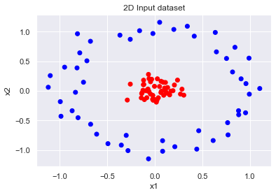

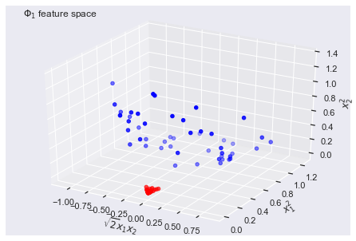

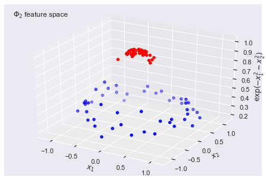

```python
import numpy as np
import seaborn as sns
from matplotlib import pyplot as plt
from mpl_toolkits.mplot3d import Axes3D
from mpl_toolkits import mplot3d
from IPython.display import HTML, Image

%matplotlib inline
sns.set()

#Generate dataset
from sklearn.datasets.samples_generator import make_circles
X, y = make_circles(100, factor=.1, noise=.1)

###################################
# Begin your code
plt.figure()
color= ['red' if elem==1 else 'blue' for elem in y ]
plt.scatter(X[:,0], X[:,1], c=color, label='data')
plt.xlabel('x1')
plt.ylabel('x2')
plt.title('2D Input dataset')

fig = plt.figure()
ax1 = Axes3D(fig) # fig.add_subplot(111, projection='3d')
ax1.scatter(np.sqrt(2)*X[:,0]*X[:,1], X[:,0]**2, X[:,1]**2, c=color, label='data')
ax1.set_xlabel('$\sqrt{2} x_1 x_2$')
ax1.set_ylabel('$ x_1^2 $')
ax1.set_zlabel('$ x_2^2 $')
# ax1.view_init(elev=30., azim=-10)
ax1.text2D(0.05, 0.95,'$\Phi_1$ feature space', transform=ax1.transAxes)


fig = plt.figure()
ax2 = Axes3D(fig) # fig.add_subplot(111, projection='3d')
ax2.scatter(X[:,0], X[:,1], np.exp(-X[:,0]**2-X[:,1]**2), c=color, label='data')
ax2.set_xlabel('$ x_1 $')
ax2.set_ylabel('$ x_2 $')
ax2.set_zlabel('$ \exp(-x_1^2-x_2^2) $')
#ax2.view_init(elev=30., azim=-10)
ax2.text2D(0.05, 0.95,'$\Phi_2$ feature space', transform=ax1.transAxes)


# End your code
###################################
```

### Question (10 points):

Using the results of your plots and the previous theoretical explanations, you should now be able to digest which of the statements below are true. Thus tick the correct boxes (several may be correct):

(1)$\quad$ [$\checkmark$ ] The kernel related to $\Phi_1$ is a polynomial kernel.  
(2)$\quad$ [$\checkmark$ ] $\Phi_2$ seems to account better for similarities between the data points.  
(3)$\quad$ [ ] $\Phi_1$ maps the data onto a sphere in the new feature space.  
(4)$\quad$ [ ] The provided dataset is linearly separable in the original space.  
(5)$\quad$ [$\checkmark$ ] The provided dataset is linearly separable in the feature space created by $\Phi_1$.  
(6)$\quad$ [$\checkmark$ ] The provided dataset is linearly separable in the feature space created by $\Phi_2$.